← Voltar ao Portal

[figure not shown]

Programa 401

# Síntese Avaliativa do Desempenho dos Programas do PPA Bahia 2024–2027

# **1 - Desempenho Global do Programa**

Este documento apresenta uma Síntese Avaliativa do Desempenho do Programa do Plano Plurianual - PPA 2024- 2027, trazendo uma visão estratégica dos seus resultados, de forma sintética, transparente e colaborativa. Serão levados em consideração o Indicador Sintético de Desempenho do Programa (ISDP), a evolução dos Indicadores de Programa, a eficácia das metas dos Indicadores de Compromisso, o desempenho da execução orçamentária-financeira e da execução física das Ações orçamentárias. O ISDP é uma síntese dessas quatro dimensões, destacando o desempenho do programa em relação aos resultados obtidos e aos esforços despendidos.  
Adicionalmente, são apresentados os principais resultados alcançados, evidenciando os avanços e conformidades dos cinco programas com melhores resultados, além das oportunidades de melhoria dos cinco, com menores resultados. Enquanto neste documento a análise abrange o programa e seus componentes de maneira sintética, nos demais relatórios, a análise detalhada evidencia o comportamento dos componentes do PPA por programas e por órgãos (https://www.ba.gov.br/seplan/monitoramento-e-avaliacao/avaliacao-do-ppa). Além desta Síntese, o [Painel BI - Boletim de Avanços e Oportunidades de Melhoria](https://app.powerbi.com/view?r=eyJrIjoiN2Q0ODliNDItZDFjZi00MGM1LTliNGEtODVmZDAwZTQ1OGEyIiwidCI6IjRjZDgzNWY0LTU0NDAtNDA4Zi05M2EzLTk3NWZjMTdjMzg0YSIsImMiOjR9) oferece informações organizadas em uma perspectiva estratégica do desempenho consolidado dos programas, detalhando, no entanto, cada componente avaliado. A análise nesta seção engloba o programa e seus componentes conforme segue:

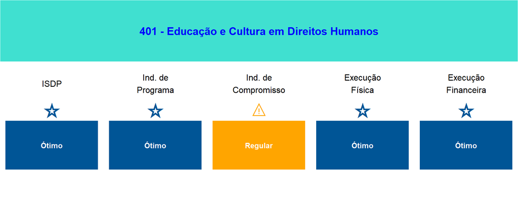

# **2 - Avanços e Conformidades no Programa**

**Indicadores de Programa:** No programa 401 - Educação e Cultura em Direitos Humanos, todos os indicadores apresentaram evolução positiva. O indicador 2180, que monitora o número de mediações de conflito realizadas, teve um forte desempenho, refletindo a otimização de estratégias, especialmente as desenvolvidas pela SJDH em 2025, que incluiu ações de prevenção de conflitos, principalmente em contextos fundiários envolvendo povos indígenas. Destacam-se também diálogos interinstitucionais, publicações de portarias declaratórias e apoio da Força Nacional no sul da Bahia, promovendo a pacificação social.  
**Indicadores de Compromisso:** No programa 401 - Educação e Cultura em Direitos Humanos, 50% dos indicadores de compromisso foram classificados como de desempenho bom ou ótimo. Um dos destaques é o indicador ‘4 - Número de pessoas com perfil de liderança social capacitadas em mediação de conflitos’, que registrou um desempenho de 106,67%. Esse resultado pode ser atribuído às oportunidades, parcerias e adesões que possibilitaram a execução das ações, especialmente considerando que, em 2025, a SJDH promoveu atividades formativas para mediação de conflitos em parceria com o Escritório de Direitos Humanos Juspopuli, por meio de um Termo de Fomento assinado em dezembro de 2024, além da busca ativa nas Caravanas de Direitos Humanos. A parceria, voltada para o projeto “Direitos Humanos e Mediação Popular de Conflitos para Convivência Comunitária Sustentável”, visa contribuir para a construção da cultura de Direitos Humanos e a redução das violações desses direitos, impulsionando interações mais justas e sustentáveis. Nesse contexto, foram realizados cursos sobre Direitos Humanos e Mediação de Conflitos, formando lideranças e contribuindo para o cumprimento da meta. Outro indicador notável, ‘1 - Número de ações educativas realizadas através de diversas modalidades’, alcançou 99,94%, evidenciando um fator positivo em relação ao histórico das ações educativas executadas em 2025, já que a meta foi quase integralmente alcançada.  
**Ações Orçamentárias:** No Programa 401 - Educação e Cultura em Direitos Humanos, 100% das ações foram classificadas como de bom ou ótimo desempenho, tanto na execução financeira quanto na execução física. Destacam-se, por exemplo, a Ação 3342 - Implantação de Coletivo Comunitário Bahia pela Paz, que apresentou execuções financeiras e físicas classificadas como Ótimas. Da mesma forma, a Ação 1522 - Promoção de Ação Educativa na Área de Direito Consumerista também apresentou resultados semelhantes, com ambos os indicadores classificados como Ótimos.

# **3 - Oportunidade de Melhoria no Programa**

**Indicadores de Programa:** No Programa 401 - Educação e Cultura em Direitos Humanos, nenhum dos indicadores apresentou evolução negativa.  
**Indicadores de Compromisso:** No programa 401 - Educação e Cultura em Direitos Humanos nenhum indicador de compromisso foi classificado como baixo ou muito baixo. Contudo, 25% dos indicadores apresentaram desempenho indeterminado e outros 25% foram considerados não aptos para avaliação. Um dos principais destaques é o indicador ‘2 - Somatório do número de pessoas capacitadas em Libras e anticapacitismo’, que superou a expectativa ao alcançar 1900%. Esse resultado se deve à alta demanda por formações não previstas inicialmente e à intensificação das ações durante o Setembro Verde, juntamente com a solicitação de capacitação por parte das prefeituras para atender novos servidores de CRAS e CREAS, aumentando a efetividade no atendimento às pessoas com deficiência.  
**Ações Orçamentárias:** No Programa 401 - Educação e Cultura em Direitos Humanos, nenhuma das ações foi classificada como de baixo ou muito baixo desempenho, tanto na execução financeira quanto na execução física.

Desenvolvido por: DAP – Diretoria de Avaliação de Políticas Públicas